# Programming For Data Science

Achmad Gunar Saadi

August 4, 2018

# 1 Introduction

## 1.1 Objectives

**Project: Reproducible Data Science**

Create R Markdown file to report your business recommendation based on your data.  
This R Markdown combines :  
a. Markdown title, author name, date  
b. Add formatting styles and hierarchical structure in your markdown (such as add title using # head, subtitle using ##, add tabset, etc)  
c. Data explanation  
d. Read your data into R  
e. Step-by-step data transformation code with some explanatory text (contain ‘chunk’ and also the markdown)  
f. Exploratory text and business recommendation based on your own creativity

## 1.2 Data Explanation

This is a dataset of retail that contain information about the transactions from 3<sup>rd</sup> January 2014 until 30<sup>th</sup> December 2017 and including 15 parameters :  
- **Row ID** – the number of row  
- **Order ID** – the ID of any transaction (order)  
- **Order Date** – the date of any transaction done  
- **Ship Date** – the date of ordered item(s) shipped  
- **Ship Mode** – the choice of ship type (First Class, Same Day, Second Class, and Standard Class)  
- **Customer ID** – the ID of customer or orderer  
- **Segment** – the segment of ordered item (Consumer, Corporate, and Home Office)  
- **Product ID** – the ID of ordered item(s)  
- **Category** – the category of ordered item(Furniture, Office Supplies, and Technology)  
- **Sub-Category** – the sub-category of ordered item  
- **Product Name** – the name of products  
- **Sales** – the sales obtained (in USD)  
- **Quantity** — the number of ordered item  
- **Discount** — the rebate. discount for the ordered item(s)  
- **Profit** — the profit of the shop from the order

## 1.3 Read and understand the Dataset

This is how the data look like (I only display the first 10 data) and including the 15 parameters mentioned before.

```r
dataRetail <- read.csv("./retail.csv")
head(dataRetail, 10)
```

```
##    Row.ID       Order.ID Order.Date Ship.Date      Ship.Mode Customer.ID
## 1       1 CA-2016-152156    11/8/16  11/11/16   Second Class    CG-12520
## 2       2 CA-2016-152156    11/8/16  11/11/16   Second Class    CG-12520
## 3       3 CA-2016-138688    6/12/16   6/16/16   Second Class    DV-13045
## 4       4 US-2015-108966   10/11/15  10/18/15 Standard Class    SO-20335
## 5       5 US-2015-108966   10/11/15  10/18/15 Standard Class    SO-20335
## 6       6 CA-2014-115812     6/9/14   6/14/14 Standard Class    BH-11710
## 7       7 CA-2014-115812     6/9/14   6/14/14 Standard Class    BH-11710
## 8       8 CA-2014-115812     6/9/14   6/14/14 Standard Class    BH-11710
## 9       9 CA-2014-115812     6/9/14   6/14/14 Standard Class    BH-11710
## 10     10 CA-2014-115812     6/9/14   6/14/14 Standard Class    BH-11710
##      Segment      Product.ID        Category Sub.Category
## 1   Consumer FUR-BO-10001798       Furniture    Bookcases
## 2   Consumer FUR-CH-10000454       Furniture       Chairs
## 3  Corporate OFF-LA-10000240 Office Supplies       Labels
```

[output cut: 29 more lines]

```r
names(dataRetail)
```

```
##  [1] "Row.ID"       "Order.ID"     "Order.Date"   "Ship.Date"
##  [5] "Ship.Mode"    "Customer.ID"  "Segment"      "Product.ID"
##  [9] "Category"     "Sub.Category" "Product.Name" "Sales"
## [13] "Quantity"     "Discount"     "Profit"
```

```r
str(dataRetail)
```

```
## 'data.frame':    9994 obs. of  15 variables:
##  $ Row.ID      : int  1 2 3 4 5 6 7 8 9 10 ...
##  $ Order.ID    : Factor w/ 5009 levels "CA-2014-100006",..: 2501 2501 2297 4373 4373 202 202 202 202 202 ...
##  $ Order.Date  : Factor w/ 1237 levels "1/1/17","1/10/14",..: 305 305 836 94 94 922 922 922 922 922 ...
##  $ Ship.Date   : Factor w/ 1334 levels "1/1/15","1/1/16",..: 220 220 907 129 129 897 897 897 897 897 ...
##  $ Ship.Mode   : Factor w/ 4 levels "First Class",..: 3 3 3 4 4 4 4 4 4 4 ...
##  $ Customer.ID : Factor w/ 793 levels "AA-10315","AA-10375",..: 144 144 240 706 706 89 89 89 89 89 ...
##  $ Segment     : Factor w/ 3 levels "Consumer","Corporate",..: 1 1 2 1 1 1 1 1 1 1 ...
##  $ Product.ID  : Factor w/ 1862 levels "FUR-BO-10000112",..: 13 56 947 320 1317 186 563 1762 795 438 ...
##  $ Category    : Factor w/ 3 levels "Furniture","Office Supplies",..: 1 1 2 1 2 1 2 3 2 2 ...
##  $ Sub.Category: Factor w/ 17 levels "Accessories",..: 5 6 11 17 15 10 3 14 4 2 ...
##  $ Product.Name: Factor w/ 1850 levels "\"While you Were Out\" Message Book, One Form per Page",..: 387 833 1440 367 574 570 1137 1099 535 295 ...
##  $ Sales       : num  262 731.9 14.6 957.6 22.4 ...
##  $ Quantity    : int  2 3 2 5 2 7 4 6 3 5 ...
##  $ Discount    : num  0 0 0 0.45 0.2 0 0 0.2 0.2 0 ...
##  $ Profit      : num  41.91 219.58 6.87 -383.03 2.52 ...
```

```r
dim(dataRetail)
```

```
## [1] 9994   15
```

The dimension of data inform that the number of data is 9994 and each has 15 parameters.  
The display give information that there are three (3) types of format data in the parameters: integer (int), categorical (Factor), numeric (num). The *Row ID* and *Quantity* parameters belong in integer type. While *Sales*, *Discount*, and *Profit* belong in numeric type. The rest parameters are factor type  
The format in *Order Date* and *Ship Date* need to be altered into Date type.  
Whilst *Order ID*, *Customer ID*, *Product ID*, and *Product Name* changed into Character type (Year/Month/Day).

```r
dataRetail$Order.Date <- as.Date(dataRetail$Order.Date, "%m/%d/%y")
dataRetail$Ship.Date <- as.Date(dataRetail$Ship.Date, "%m/%d/%y")
dataRetail$Order.ID <- as.character(dataRetail$Order.ID)
dataRetail$Customer.ID <- as.character(dataRetail$Customer.ID)
dataRetail$Product.ID <- as.character(dataRetail$Product.ID)
dataRetail$Product.Name <- as.character(dataRetail$Product.Name)
str(dataRetail)
```

```
## 'data.frame':    9994 obs. of  15 variables:
##  $ Row.ID      : int  1 2 3 4 5 6 7 8 9 10 ...
##  $ Order.ID    : chr  "CA-2016-152156" "CA-2016-152156" "CA-2016-138688" "US-2015-108966" ...
##  $ Order.Date  : Date, format: "2016-11-08" "2016-11-08" ...
##  $ Ship.Date   : Date, format: "2016-11-11" "2016-11-11" ...
##  $ Ship.Mode   : Factor w/ 4 levels "First Class",..: 3 3 3 4 4 4 4 4 4 4 ...
##  $ Customer.ID : chr  "CG-12520" "CG-12520" "DV-13045" "SO-20335" ...
##  $ Segment     : Factor w/ 3 levels "Consumer","Corporate",..: 1 1 2 1 1 1 1 1 1 1 ...
##  $ Product.ID  : chr  "FUR-BO-10001798" "FUR-CH-10000454" "OFF-LA-10000240" "FUR-TA-10000577" ...
##  $ Category    : Factor w/ 3 levels "Furniture","Office Supplies",..: 1 1 2 1 2 1 2 3 2 2 ...
##  $ Sub.Category: Factor w/ 17 levels "Accessories",..: 5 6 11 17 15 10 3 14 4 2 ...
##  $ Product.Name: chr  "Bush Somerset Collection Bookcase" "Hon Deluxe Fabric Upholstered Stacking Chairs, Rounded Back" "Self-Adhesive Address Labels for Typewriters by Universal" "Bretford CR4500 Series Slim Rectangular Table" ...
##  $ Sales       : num  262 731.9 14.6 957.6 22.4 ...
##  $ Quantity    : int  2 3 2 5 2 7 4 6 3 5 ...
##  $ Discount    : num  0 0 0 0.45 0.2 0 0 0.2 0.2 0 ...
##  $ Profit      : num  41.91 219.58 6.87 -383.03 2.52 ...
```

Below is the quick look of distribution or descriptive statistics character of the data each parameters.

```r
summary(dataRetail)
```

```
##      Row.ID       Order.ID           Order.Date
##  Min.   :   1   Length:9994        Min.   :2014-01-03
##  1st Qu.:2499   Class :character   1st Qu.:2015-05-23
##  Median :4998   Mode  :character   Median :2016-06-26
##  Mean   :4998                      Mean   :2016-04-30
##  3rd Qu.:7496                      3rd Qu.:2017-05-14
##  Max.   :9994                      Max.   :2017-12-30
##
##    Ship.Date                   Ship.Mode    Customer.ID
##  Min.   :2014-01-07   First Class   :1538   Length:9994
##  1st Qu.:2015-05-27   Same Day      : 543   Class :character
##  Median :2016-06-29   Second Class  :1945   Mode  :character
##  Mean   :2016-05-03   Standard Class:5968
##  3rd Qu.:2017-05-18
##  Max.   :2018-01-05
##
##         Segment      Product.ID                   Category
##  Consumer   :5191   Length:9994        Furniture      :2121
##  Corporate  :3020   Class :character   Office Supplies:6026
##  Home Office:1783   Mode  :character   Technology     :1847
##
##
##
##
##       Sub.Category  Product.Name           Sales              Quantity
##  Binders    :1523   Length:9994        Min.   :    0.444   Min.   : 1.00
##  Paper      :1370   Class :character   1st Qu.:   17.280   1st Qu.: 2.00
##  Furnishings: 957   Mode  :character   Median :   54.490   Median : 3.00
##  Phones     : 889                      Mean   :  229.858   Mean   : 3.79
##  Storage    : 846                      3rd Qu.:  209.940   3rd Qu.: 5.00
##  Art        : 796                      Max.   :22638.480   Max.   :14.00
##  (Other)    :3613
##     Discount          Profit
##  Min.   :0.0000   Min.   :-6599.978
##  1st Qu.:0.0000   1st Qu.:    1.729
##  Median :0.2000   Median :    8.666
##  Mean   :0.1562   Mean   :   28.657
##  3rd Qu.:0.2000   3rd Qu.:   29.364
##  Max.   :0.8000   Max.   : 8399.976
##
```

There are some interesting facts based on our descriptive statistics info:  
1. Ship mode –> Standard Class is far more famous than the other ship mode by 5968. 2. Category –> Office Supplies category is far more dominant than the other by 6026  
3. Sub-category –> the top two most favorite sub-category are *Binders* (1523) and *Paper* (1370) which both of them categorized in Office Supplies Category  
4.Sales –> there is such like outlier or something value that prominent looking the descriptive information where tthere is huge gap between mean (229.858) or 3rd quartile (209.94) and the max value (22638.48)  
5. Profit –> There is huge gap between mean or 3th quartile and min and max value  
6. The case in Sales parameter also likely happended in Quartile and Discount parameters

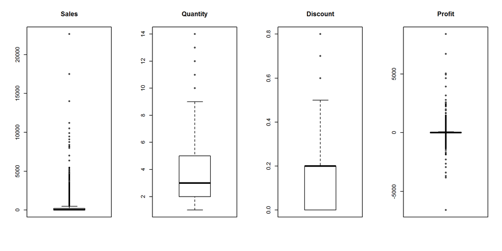

```r
par(mfrow=c(1,4), pty = "m")
boxplot(dataRetail$Sales);title("Sales")
boxplot(dataRetail$Quantity);title("Quantity")
boxplot(dataRetail$Discount);title("Discount")
boxplot(dataRetail$Profit);title("Profit")
```

# 2 Exploring the Data

## 2.1 Which product segment makes up our high-value transaction (sales)?

Generally, **Technology** make the high-value transaction by 836154 stand above Furniture (741999.8) and Office Supplies(719047).  
And **Phone** standout as the highest value transaction by 330007.05 followed by **Chairs** (328449.1) which depicted by the heatmap as well (white color zone).

```r
rowSums(xtabs(Sales~ Sub.Category + Category, dataRetail))
```

```
## Accessories  Appliances         Art     Binders   Bookcases      Chairs
##   167380.32   107532.16    27118.79   203412.73   114880.00   328449.10
##     Copiers   Envelopes   Fasteners Furnishings      Labels    Machines
##   149528.03    16476.40     3024.28    91705.16    12486.31   189238.63
##       Paper      Phones     Storage    Supplies      Tables
##    78479.21   330007.05   223843.61    46673.54   206965.53
```

```r
xtabs(Sales~ Sub.Category + Category, dataRetail)
```

```
##              Category
## Sub.Category  Furniture Office Supplies Technology
##   Accessories      0.00            0.00  167380.32
##   Appliances       0.00       107532.16       0.00
##   Art              0.00        27118.79       0.00
##   Binders          0.00       203412.73       0.00
##   Bookcases   114880.00            0.00       0.00
##   Chairs      328449.10            0.00       0.00
##   Copiers          0.00            0.00  149528.03
##   Envelopes        0.00        16476.40       0.00
##   Fasteners        0.00         3024.28       0.00
##   Furnishings  91705.16            0.00       0.00
##   Labels           0.00        12486.31       0.00
##   Machines         0.00            0.00  189238.63
##   Paper            0.00        78479.21       0.00
##   Phones           0.00            0.00  330007.05
##   Storage          0.00       223843.61       0.00
##   Supplies         0.00        46673.54       0.00
##   Tables      206965.53            0.00       0.00
```

```r
colSums(xtabs(Sales~ Sub.Category + Category, dataRetail))
```

```
##       Furniture Office Supplies      Technology
##        741999.8        719047.0        836154.0
```

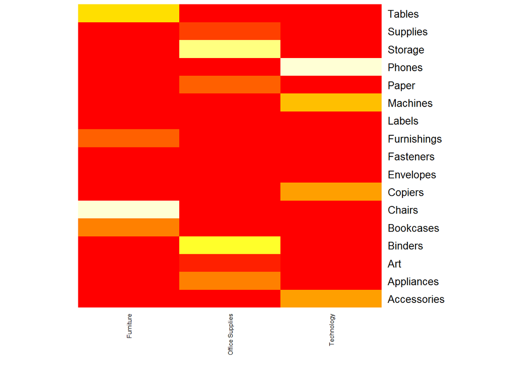

```r
heatmap(xtabs(Sales~ Sub.Category + Category, dataRetail), Colv = NA, Rowv = NA, cexCol = 0.6,scale = "column")
```

## 2.2 The most profitable by category, sub-category and shipment mode?

The profit based on shipment mode itself is *not very significant* for each type.

```r
aggregate(Profit ~ Ship.Mode, dataRetail, mean)
```

```
##        Ship.Mode   Profit
## 1    First Class 31.83995
## 2       Same Day 29.26659
## 3   Second Class 29.53555
## 4 Standard Class 27.49477
```

Whereas **Copiers** significantly stands as the most profitable sub-category by 1233.198 using **First Class** shipment.

```r
d2<-aggregate(Profit ~ Sub.Category+Ship.Mode, dataRetail, mean)
d2[which.max(d2$Profit),]
```

```
##   Sub.Category   Ship.Mode   Profit
## 7      Copiers First Class 1233.198
```

```r
d2
```

```
##    Sub.Category      Ship.Mode      Profit
## 1   Accessories    First Class   46.151665
## 2    Appliances    First Class   46.629751
## 3           Art    First Class    6.699554
## 4       Binders    First Class   17.272563
## 5     Bookcases    First Class   -6.244847
## 6        Chairs    First Class   31.120175
## 7       Copiers    First Class 1233.198275
## 8     Envelopes    First Class   31.299878
## 9     Fasteners    First Class    4.235840
## 10  Furnishings    First Class   14.336277
## 11       Labels    First Class   13.411920
## 12     Machines    First Class  -69.717348
## 13        Paper    First Class   22.669581
## 14       Phones    First Class   60.871522
```

[output cut: 54 more lines]

Meanwhile, **Technology** far more profiteable than other categories either using *First Class, Same Day, Second Class, or Standard Class shipment*.

```r
aggregate(Profit ~ Category+Ship.Mode, dataRetail, mean)
```

```
##           Category      Ship.Mode    Profit
## 1        Furniture    First Class  9.379044
## 2  Office Supplies    First Class 20.220142
## 3       Technology    First Class 91.370643
## 4        Furniture       Same Day  6.700407
## 5  Office Supplies       Same Day 19.704047
## 6       Technology       Same Day 88.478483
## 7        Furniture   Second Class  9.897568
## 8  Office Supplies   Second Class 23.496673
## 9       Technology   Second Class 71.454116
## 10       Furniture Standard Class  8.301855
## 11 Office Supplies Standard Class 19.405933
## 12      Technology Standard Class 76.829286
```

## 2.3 The average monthly Profit and the most favorite item each month

### 2.3.1 The average Profit by month and day

From the plotting of profit, there are some outliers so that better used median function to describe the aggregate profit by month and day. On August profit can be obtained the most than other months. Whereas the profit by day, either using median or mean function, showed that wednesday is surely the best day if it comes to profit.

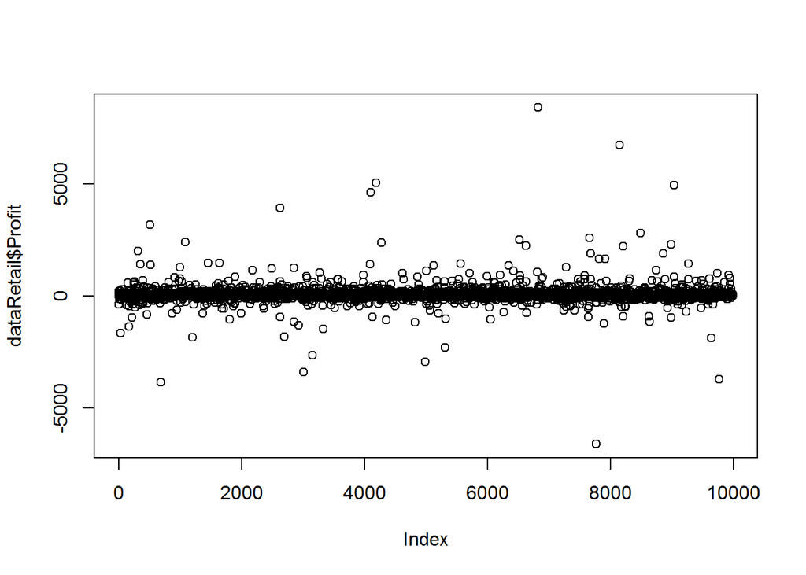

```r
dataRetail$Month<-months(dataRetail$Order.Date)
dataRetail$Day<-weekdays(dataRetail$Order.Date)
plot(dataRetail$Profit)
```

```r
aggregate(Profit~ Month,dataRetail, median)
```

```
##        Month   Profit
## 1      April  6.55295
## 2     August 10.58510
## 3   December  9.33120
## 4   February  8.47530
## 5    January  7.59920
## 6       July  8.31840
## 7       June  9.01710
## 8      March  8.68840
## 9        May  9.10200
## 10  November  8.99100
## 11   October  7.47520
## 12 September  8.27820
```

```r
aggregate(Profit~ Day,dataRetail, mean)
```

```
##         Day   Profit
## 1    Friday 25.58901
## 2    Monday 27.53133
## 3  Saturday 24.94116
## 4    Sunday 33.40907
## 5  Thursday 27.12492
## 6   Tuesday 32.16124
## 7 Wednesday 39.63307
```

```r
aggregate(Profit~ Day,dataRetail, median)
```

```
##         Day  Profit
## 1    Friday  8.8026
## 2    Monday  8.3104
## 3  Saturday  8.5728
## 4    Sunday  8.3550
## 5  Thursday  8.6715
## 6   Tuesday  8.7234
## 7 Wednesday 10.4650
```

### 2.3.2 The most favorite item each month

The list of favorite item per month dominated by **Technoloy** 9 out of 12 months and the rest is **Office Supplies** category.  
**Copiers**, **Phone**, and ***Binders** standout as the most favorite item by month by dominate 3 out of 12 months each. The second is **Accesories** by 2 out of 12 months.

```r
m1<-aggregate(Profit~Category+Sub.Category+Month,dataRetail[dataRetail$Month=="January",],sum)
m2<-aggregate(Profit~Category+Sub.Category+Month,dataRetail[dataRetail$Month=="February",],sum)
m3<-aggregate(Profit~Category+Sub.Category+Month,dataRetail[dataRetail$Month=="March",],sum)
m4<-aggregate(Profit~Category+Sub.Category+Month,dataRetail[dataRetail$Month=="April",],sum)
m5<-aggregate(Profit~Category+Sub.Category+Month,dataRetail[dataRetail$Month=="May",],sum)
m6<-aggregate(Profit~Category+Sub.Category+Month,dataRetail[dataRetail$Month=="June",],sum)
m7<-aggregate(Profit~Category+Sub.Category+Month,dataRetail[dataRetail$Month=="July",],sum)
m8<-aggregate(Profit~Category+Sub.Category+Month,dataRetail[dataRetail$Month=="August",],sum)
m9<-aggregate(Profit~Category+Sub.Category+Month,dataRetail[dataRetail$Month=="September",],sum)
m10<-aggregate(Profit~Category+Sub.Category+Month,dataRetail[dataRetail$Month=="October",],sum)
m11<-aggregate(Profit~Category+Sub.Category+Month,dataRetail[dataRetail$Month=="November",],sum)
m12<-aggregate(Profit~Category+Sub.Category+Month,dataRetail[dataRetail$Month=="December",],sum)

m1[which.max(m1$Profit),]
```

```
##          Category Sub.Category   Month   Profit
## 4 Office Supplies      Binders January 2851.659
```

```r
m2[which.max(m2$Profit),]
```

```
##      Category Sub.Category    Month   Profit
## 11 Technology     Machines February 2838.981
```

```r
m3[which.max(m3$Profit),]
```

```
##     Category Sub.Category Month  Profit
## 7 Technology      Copiers March 11044.4
```

```r
m4[which.max(m4$Profit),]
```

```
##      Category Sub.Category Month   Profit
## 14 Technology       Phones April 2164.461
```

```r
m5[which.max(m5$Profit),]
```

```
##     Category Sub.Category Month   Profit
## 7 Technology      Copiers   May 3719.949
```

```r
m6[which.max(m6$Profit),]
```

```
##      Category Sub.Category Month  Profit
## 14 Technology       Phones  June 4204.51
```

```r
m7[which.max(m7$Profit),]
```

```
##     Category Sub.Category Month   Profit
## 1 Technology  Accessories  July 4783.981
```

```r
m8[which.max(m8$Profit),]
```

```
##          Category Sub.Category  Month   Profit
## 4 Office Supplies      Binders August 4262.903
```

```r
m9[which.max(m9$Profit),]
```

```
##          Category Sub.Category     Month Profit
## 4 Office Supplies      Binders September 7441.5
```

```r
m10[which.max(m10$Profit),]
```

```
##     Category Sub.Category   Month  Profit
## 7 Technology      Copiers October 15863.9
```

```r
m11[which.max(m11$Profit),]
```

```
##      Category Sub.Category    Month   Profit
## 14 Technology       Phones November 7734.028
```

```r
m12[which.max(m12$Profit),]
```

```
##     Category Sub.Category    Month   Profit
## 1 Technology  Accessories December 7509.024
```

# 3 Business Recommendation

The data exploration shows that generally **Technology** category more dominant than other categories in profit context, either used any shipment modes.  
The dominance of technology category represented by **Phone** and **Copiers** sub-category that the two most profitable throughout years period.  
If it comes to sales, **Technology** category and **Phone** sub-category also dominated.  
The dominance that showed by Technology and its sub-categories throuth most of the months indicated that the items related to technology are the most favorite and will be the favorite for near-future term at least. The business strategy has to accommodate this opportunity especially for the most profitable months like August and midweek (Wednesday).